# HW4

Nicole Higgins

2023-02-20

### Q0 Collaborators

Who did you work with on this assignment? You’ll get a bonus 5 points if you name someone and they name you. *No scores above 100% are allowed, but these bonus points can repair mistakes on this assignment*.

**I worked with Jonny**

### Q1: Sherman-Morrison

Let $v$ and $w$ be vectors in $\mathbb{R}^n$ and let $A = I + w v^T$. A matrix like $A$ is called a “rank-one perturbation of the identity.” Assuming $v^Tw\neq -1$, let
$$B = I - \frac{1}{1+v^Tw}w
v^T.$$
In this problem your goal is to prove on paper that $B = A^{-1}$. *Hint:* $B$ is the inverse of $A$ if $AB=I$. Alternately, you can let $z$ be an arbitrary vector in $\mathbb{R}^n$ and show that $ABz=z$. This problem is a special case of a famous identity known as the Sherman-Morrison formula.

**Proof below:**

$(I + wv^T) (I - \frac{1}{1+v^Tw}wv^T) = I\\ I +wv^T - \frac{wv^T}{1+v^Tw}-\frac{wv^T wv^T}{1+v^Tw}=I\\I + wv^T-(\frac{wv^T+wv^Twv^T}{1+v^Tw})=I\\I + wv^T - \frac{wv^T(1+v^Tw)}{1+v^Tw}=I\\I + wv^T-wv^T=I\\I=I$

### Q2: Derivative matrix

In this problem we’ll build a $7\times7$ matrix that can take derivatives. We’ll let any vector $c\in\mathbb{R}^7$ represent a trigonometric polynomial of degree 3. Specifically, let
$$f_c(x) = c_1 + c_2\cos x + c_3\sin x +
c_4\cos(2x) + c_5\sin(2x) + c_6\cos(3x) + c_7\sin(3x)$$
Let’s suppose $c$ and $d$ are two vectors in $\mathbb{R}^7$, and the corresponding functions are $f_c$ and $f_d$. If the derivative of $f_c$ is $f_d$, that is, $f_c'(x) = f_d(x)$, then we can find the entries of $d$ if we know the entries of $c$. For example, if $c^T = (0,2,0,0,0,0,0)$ then we would have $d^T = (0,0,-2,0,0,0,0)$ because the derivative of $2\cos(x)$ is $-2\sin(x)$. In particular, $Ac = d$ where $A$ is a certain $7\times7$ matrix with 43 zeros. Find this matrix $A$. Then show that it works by creating and describing a simple example where you find the derivative of some trig polynomial both by hand and also by multiplication with $A$.

```r
library("magick")
```

```
##   format width height colorspace matte filesize density
## 1    PNG  2251    908       sRGB FALSE   454079   72x72
```

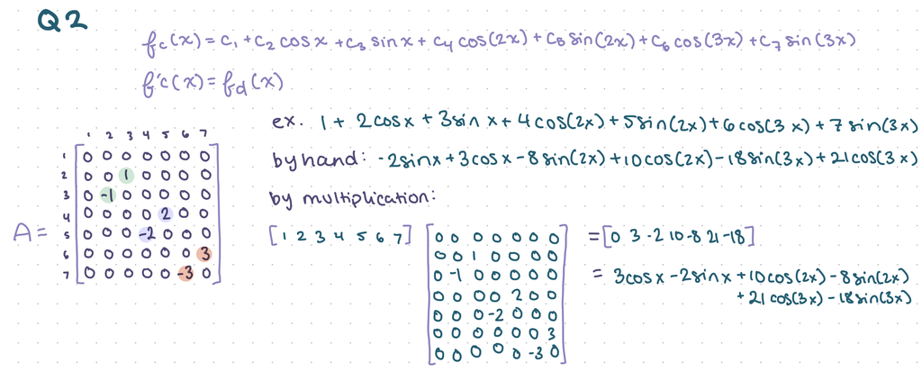

```r
q2 = image_read("HW4Q2.png")
print(q2)
```

### Q3: Theft

The point of this problem is twofold: (i) to illustrate what can happen if you accumulate many truncations of numbers and (ii) to give you practice writing programs.

```r
# initialize values
accounts = runif(10000, 100, 100000)
illAcc = 0
iRate = 1+0.05/365 # turned the rate into a multiplier
days = 0

while(illAcc < 1000000){
  # until the illegal account reaches 1,000,000, keep stealing truncated cents
  days = days + 1

  accounts = accounts*iRate # adds daily interest
  accountsTru = floor(accounts*100)/100 # truncating accounts
  truncs = sum(accounts - accountsTru) # truncations

  illAcc = illAcc + truncs # adding truncation
  illAcc = illAcc*iRate # daily interest of illegal account
  accounts = accountsTru # letting accounts equal their truncated version
}

# prints the number of years that have passed
print(days/365)
```

```
## [1] 26.37534
```

### Q4 Timing of A = QR

Let’s see how large a matrix $A$ you could factor into $QR$ if you had an hour of computing time on your machine.

- Make a random $100\times100$ matrix $A$ and time the factorization $A = QR$ using our code and the built-in one. *Our code is in the activity from the A=QR day in the course spreadsheet.* Which is faster?

```r
# creating a 100x100 matrix with values 0-50
vals = sample(0:50, 10000, replace = TRUE)
A100 = matrix(vals, 100, 100)

# timing the factorization
tStart = Sys.time()

A100QR <- my.QR(A100)

tEnd <- Sys.time()
print(tEnd - tStart)
```

```
## Time difference of 0.06916499 secs
```

```r
# creating a 100x100 matrix with values 0-50
vals = sample(0:50, 10000, replace = TRUE)
B100 = matrix(vals, 100, 100)

# timing the factorization
tStart = Sys.time()

B100QR <- qr(B100)

tEnd <- Sys.time()
print(tEnd - tStart)
```

```
## Time difference of 0.005650043 secs
```

- Now try a $200\times200$ matrix and a $400\times400$ matrix. Use the built-in code. Complete the sentence: “When I double the dimension of $A$, the computation time for $A = QR$ gets multiplied by approximately a factor of ???”.

**Built in factorization of a 200x200 matrix:**

```r
# creating a 200x200 matrix with values 0-50
vals = sample(0:50, 40000, replace = TRUE)
B200 = matrix(vals, 200, 200)

# timing the factorization
tStart = Sys.time()

B200QR <- qr(B200)

tEnd <- Sys.time()
print(tEnd - tStart)
```

```
## Time difference of 0.007023096 secs
```

**Built in factorization of a 400x400 matrix:**

```r
# creating a 200x200 matrix with values 0-50
vals = sample(0:50, 160000, replace = TRUE)
B400 = matrix(vals, 400, 400)

# timing the factorization
tStart = Sys.time()

B400QR <- qr(B400)

tEnd <- Sys.time()
print(tEnd - tStart)
```

```
## Time difference of 0.04032087 secs
```

- An hour is 3600 seconds. Predict how large a matrix you can factor in one hour on your machine.

### Q5 A rank-one matrix is not invertible

Let $A = \begin{pmatrix} -1&1&-2\\2&-2&4\\4&-4&8 \end{pmatrix}$ and let $b = (5,-10,-12)$.

- Show that $A$ has rank one by finding $u,v\in\mathbb{R}^3$ such that $A = uv^T$.
- Because rank-one matrices are not invertible, we know that the equation $Ax=b$ has either infinitely many solutions or none. If there is no $x$ with $Ax=b$, explain why not. If there are infinitely many $x$ with $Ax=b$, give two examples.

```
##   format width height colorspace matte filesize density
## 1   JPEG  2388    786       sRGB FALSE   186110   72x72
```

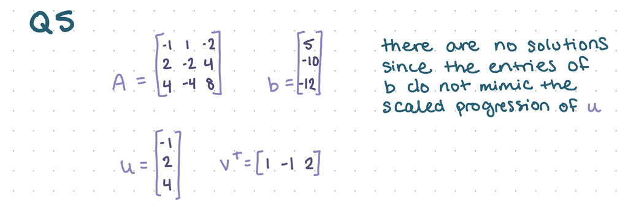

```r
q5 = image_read("HW4Q5.jpg")
print(q5)
```

### Q6 Lion, Tiger, Pencil

A “Word2vec” algorithm can produce vectors in $\mathbb{R}^{300}$ that correspond in some way to each English word. To do this, the algorithm trains on a massive data set containing many English-language text files, for example, news articles. These algorithms are notorious for carefully learning the prejudices of the authors of the training texts. Here is a recent and nuanced discussion of the issue, which you can explore if you like: [link](https://arxiv.org/abs/1905.09866).

Next comes a long code listing that doesn’t actually appear in the knitted file, because of the handy “echo=FALSE” option. It defines eight vectors whose names are: *octopus, snail, lion, tiger, cat, horse, beetle, pencil.* I got these vectors by playing with the *gensim* package in Python.

Concretely, the 19th of the 300 entries in the **tiger** vector is:

```r
tiger[19]
```

```
## [1] -0.2451172
```

Consider the word *tiger*. Among the other seven, I think *lion* is semantically closest, followed by *cat*. Then the next few are harder for me to rank. I might say that *horse* comes next because it’s large and lives on land, then *octopus* which is large but aquatic. *Snail* and *beetle* are living things but otherwise quite far from being tigers. Finally, I think *pencil* is completely unrelated to *tiger*. The R Markdown formatting lets me rank them in a table like this:

| Word | Similarity to “tiger,” in my opinion |
| --- | --- |
| lion | very close |
| cat | close |
| horse | kind of close |
| octopus | kind of far |
| snail | far |
| beetle | far |
| pencil | very far |

But that’s subjective; it’s informed by my own life experiences and priorities! For example, someone else might argue that horses eat plants, so they should be lower than octopuses in the table.

The word2vec embedding allows us to explore the distances between these words in a quantitative way, *within the flawed word2vec language model*. A typical way to think about the distance between two words is from the dot product.

```r
lion %*% tiger/(norm(tiger, type="2") * norm(lion, type="2"))
```

```
##           [,1]
## [1,] 0.5121041
```

```r
cat %*% tiger/(norm(tiger, type="2") * norm(cat, type="2"))
```

```
##           [,1]
## [1,] 0.5172962
```

```r
horse %*% tiger/(norm(tiger, type="2") * norm(horse, type="2"))
```

```
##           [,1]
## [1,] 0.2876559
```

```r
octopus %*% tiger/(norm(tiger, type="2") * norm(octopus, type="2"))
```

```
##           [,1]
## [1,] 0.2439948
```

```r
snail %*% tiger/(norm(tiger, type="2") * norm(snail, type="2"))
```

```
##           [,1]
## [1,] 0.2244429
```

```r
beetle %*% tiger/(norm(tiger, type="2") * norm(beetle, type="2"))
```

```
##           [,1]
## [1,] 0.3287175
```

```r
pencil %*% tiger/(norm(tiger, type="2") * norm(pencil, type="2"))
```

```
##           [,1]
## [1,] 0.1348347
```

| Word | Similarity to “tiger,” according to $\frac{v^Tw}{\\|v\\|\\|w\\|}$ |
| --- | --- |
| cat | 0.5172961902020222 |
| lion | 0.5121040788731422 |
| beetle | 0.3287175047393056 |
| horse | 0.2876559461603138 |
| octopus | 0.2439948086041927 |
| snail | 0.2244429287752359 |
| pencil | 0.1348347049613083 |